# Module5_COVID19_Project

STUDENT XYZ

2026-09-11

## Report Analysis Target

**Overall, the report wishes to analyze COVID19 data from a global perspective and a US perspective.**

**The first question** of interest is how the US death rate per confirmed case compares to other countries from around the globe.

**The second question** of interest is the dynamic of death rates per capita and COVID cases per capita across the US. The US data allows the extra analysis since the underlying data contains population information. My theory is the more cases there are per capita, the more overwhelmed the health system will be, causing more deaths per capita.

**The final question** area of interest is are state per capita COVID death rates in 2021 predictive of 2022.

## Importing Data

- The data is from Johns Hopkins Github site.
- This data set deals with COVID19.
  - A call is made out to the website to read the csv file of data in
  - All data sets are imported.
- The data sets include confirmed cases and deaths, as well as US and global information. The data sets are:
  - COVID19 cases confirmed in the US.
  - COVID19 cases confirmed globally.
  - COVID19 deaths in the US.
  - COVID19 deaths globally.
- Data commentary overall:
  - In general the US data has more information and detail.
  - The US data has FIPS code, the administration/city area, and province/state .
  - The US death data has population as well.
  - The global information does not have population. Countries are listed, but only select countries have province/state filled.
  - Both data sets contain daily observations from 01/22/2020 to 03/09/2023

```r
# Loading the tidyverse library
library(tidyverse)
# Loading MLmetrics to calculate GINI value
library(MLmetrics)
# Loading the lubridate library
library(lubridate)

# Load in the data sets
# Since all five data sets have same beginning url, setting up string concatenation

#Lead url
url_in <- "https://raw.githubusercontent.com/CSSEGISandData/COVID-19/master/csse_covid_19_data/csse_covid_19_time_series/"

covid19_confirmed_US <- readr::read_csv(str_c(url_in, "time_series_covid19_confirmed_US.csv"))
covid19_confirmed_global <- readr::read_csv(str_c(url_in, "time_series_covid19_confirmed_global.csv"))
covid19_deaths_US <- readr::read_csv(str_c(url_in, "time_series_covid19_deaths_US.csv"))
covid19_deaths_global <- readr::read_csv(str_c(url_in, "time_series_covid19_deaths_global.csv"))
```

## Initial Data Summary and Cleaning

- Doing an initial exploration of the COVID data
  - Previously loaded the *tidyverse* library
  - Doing an initial look at the data
  - The data is in the correct, character/numeric format, so no changes needed there
- Removing some columns not needed
  - Taking out Lat and Long (Long_ and Long are used in the different data sets as names)
  - Taking out other UID, iso2, iso3, code3, FIPS, Admin, and Combined Key columns
- Columns with high missing rates - the province data - in the global data set is removed
- The data per date is in column, I want to pivot that information to be in rows
- Also renaming the province/state fields
- After pivoting, want to aggregate the data by year
- Then want to join the US data of cases and deaths together, along with population by state
- Want to join the global data of cases and deaths together
- US State/province data has some smaller territories, so will filter out, will keep DC and Puerto Rico though.

```r
# Doing an initial view of the data
print(covid19_confirmed_US[1:10,])
```

```
## # A tibble: 10 × 1,154
##         UID iso2  iso3  code3  FIPS Admin2   Province_State Country_Region   Lat
##       <dbl> <chr> <chr> <dbl> <dbl> <chr>    <chr>          <chr>          <dbl>
##  1 84001001 US    USA     840  1001 Autauga  Alabama        US              32.5
##  2 84001003 US    USA     840  1003 Baldwin  Alabama        US              30.7
##  3 84001005 US    USA     840  1005 Barbour  Alabama        US              31.9
##  4 84001007 US    USA     840  1007 Bibb     Alabama        US              33.0
##  5 84001009 US    USA     840  1009 Blount   Alabama        US              34.0
##  6 84001011 US    USA     840  1011 Bullock  Alabama        US              32.1
##  7 84001013 US    USA     840  1013 Butler   Alabama        US              31.8
##  8 84001015 US    USA     840  1015 Calhoun  Alabama        US              33.8
##  9 84001017 US    USA     840  1017 Chambers Alabama        US              32.9
## 10 84001019 US    USA     840  1019 Cherokee Alabama        US              34.2
## # ℹ 1,145 more variables: Long_ <dbl>, Combined_Key <chr>, `1/22/20` <dbl>,
## #   `1/23/20` <dbl>, `1/24/20` <dbl>, `1/25/20` <dbl>, `1/26/20` <dbl>,
## #   `1/27/20` <dbl>, `1/28/20` <dbl>, `1/29/20` <dbl>, `1/30/20` <dbl>,
## #   `1/31/20` <dbl>, `2/1/20` <dbl>, `2/2/20` <dbl>, `2/3/20` <dbl>,
## #   `2/4/20` <dbl>, `2/5/20` <dbl>, `2/6/20` <dbl>, `2/7/20` <dbl>,
## #   `2/8/20` <dbl>, `2/9/20` <dbl>, `2/10/20` <dbl>, `2/11/20` <dbl>,
## #   `2/12/20` <dbl>, `2/13/20` <dbl>, `2/14/20` <dbl>, `2/15/20` <dbl>, …
```

```r
print(covid19_confirmed_global[1:10,])
```

```
## # A tibble: 10 × 1,147
##    `Province/State`  `Country/Region`   Lat   Long `1/22/20` `1/23/20` `1/24/20`
##    <chr>             <chr>            <dbl>  <dbl>     <dbl>     <dbl>     <dbl>
##  1 <NA>              Afghanistan       33.9  67.7          0         0         0
##  2 <NA>              Albania           41.2  20.2          0         0         0
##  3 <NA>              Algeria           28.0   1.66         0         0         0
##  4 <NA>              Andorra           42.5   1.52         0         0         0
##  5 <NA>              Angola           -11.2  17.9          0         0         0
##  6 <NA>              Antarctica       -71.9  23.3          0         0         0
##  7 <NA>              Antigua and Bar…  17.1 -61.8          0         0         0
##  8 <NA>              Argentina        -38.4 -63.6          0         0         0
##  9 <NA>              Armenia           40.1  45.0          0         0         0
## 10 Australian Capit… Australia        -35.5 149.           0         0         0
## # ℹ 1,140 more variables: `1/25/20` <dbl>, `1/26/20` <dbl>, `1/27/20` <dbl>,
## #   `1/28/20` <dbl>, `1/29/20` <dbl>, `1/30/20` <dbl>, `1/31/20` <dbl>,
## #   `2/1/20` <dbl>, `2/2/20` <dbl>, `2/3/20` <dbl>, `2/4/20` <dbl>,
## #   `2/5/20` <dbl>, `2/6/20` <dbl>, `2/7/20` <dbl>, `2/8/20` <dbl>,
## #   `2/9/20` <dbl>, `2/10/20` <dbl>, `2/11/20` <dbl>, `2/12/20` <dbl>,
## #   `2/13/20` <dbl>, `2/14/20` <dbl>, `2/15/20` <dbl>, `2/16/20` <dbl>,
## #   `2/17/20` <dbl>, `2/18/20` <dbl>, `2/19/20` <dbl>, `2/20/20` <dbl>, …
```

```r
print(covid19_deaths_US[1:10,])
```

```
## # A tibble: 10 × 1,155
##         UID iso2  iso3  code3  FIPS Admin2   Province_State Country_Region   Lat
##       <dbl> <chr> <chr> <dbl> <dbl> <chr>    <chr>          <chr>          <dbl>
##  1 84001001 US    USA     840  1001 Autauga  Alabama        US              32.5
##  2 84001003 US    USA     840  1003 Baldwin  Alabama        US              30.7
##  3 84001005 US    USA     840  1005 Barbour  Alabama        US              31.9
##  4 84001007 US    USA     840  1007 Bibb     Alabama        US              33.0
##  5 84001009 US    USA     840  1009 Blount   Alabama        US              34.0
##  6 84001011 US    USA     840  1011 Bullock  Alabama        US              32.1
##  7 84001013 US    USA     840  1013 Butler   Alabama        US              31.8
##  8 84001015 US    USA     840  1015 Calhoun  Alabama        US              33.8
##  9 84001017 US    USA     840  1017 Chambers Alabama        US              32.9
## 10 84001019 US    USA     840  1019 Cherokee Alabama        US              34.2
## # ℹ 1,146 more variables: Long_ <dbl>, Combined_Key <chr>, Population <dbl>,
## #   `1/22/20` <dbl>, `1/23/20` <dbl>, `1/24/20` <dbl>, `1/25/20` <dbl>,
## #   `1/26/20` <dbl>, `1/27/20` <dbl>, `1/28/20` <dbl>, `1/29/20` <dbl>,
## #   `1/30/20` <dbl>, `1/31/20` <dbl>, `2/1/20` <dbl>, `2/2/20` <dbl>,
## #   `2/3/20` <dbl>, `2/4/20` <dbl>, `2/5/20` <dbl>, `2/6/20` <dbl>,
## #   `2/7/20` <dbl>, `2/8/20` <dbl>, `2/9/20` <dbl>, `2/10/20` <dbl>,
## #   `2/11/20` <dbl>, `2/12/20` <dbl>, `2/13/20` <dbl>, `2/14/20` <dbl>, …
```

```r
print(covid19_deaths_global[1:10,])
```

```
## # A tibble: 10 × 1,147
##    `Province/State`  `Country/Region`   Lat   Long `1/22/20` `1/23/20` `1/24/20`
##    <chr>             <chr>            <dbl>  <dbl>     <dbl>     <dbl>     <dbl>
##  1 <NA>              Afghanistan       33.9  67.7          0         0         0
##  2 <NA>              Albania           41.2  20.2          0         0         0
##  3 <NA>              Algeria           28.0   1.66         0         0         0
##  4 <NA>              Andorra           42.5   1.52         0         0         0
##  5 <NA>              Angola           -11.2  17.9          0         0         0
##  6 <NA>              Antarctica       -71.9  23.3          0         0         0
##  7 <NA>              Antigua and Bar…  17.1 -61.8          0         0         0
##  8 <NA>              Argentina        -38.4 -63.6          0         0         0
##  9 <NA>              Armenia           40.1  45.0          0         0         0
## 10 Australian Capit… Australia        -35.5 149.           0         0         0
## # ℹ 1,140 more variables: `1/25/20` <dbl>, `1/26/20` <dbl>, `1/27/20` <dbl>,
## #   `1/28/20` <dbl>, `1/29/20` <dbl>, `1/30/20` <dbl>, `1/31/20` <dbl>,
## #   `2/1/20` <dbl>, `2/2/20` <dbl>, `2/3/20` <dbl>, `2/4/20` <dbl>,
## #   `2/5/20` <dbl>, `2/6/20` <dbl>, `2/7/20` <dbl>, `2/8/20` <dbl>,
## #   `2/9/20` <dbl>, `2/10/20` <dbl>, `2/11/20` <dbl>, `2/12/20` <dbl>,
## #   `2/13/20` <dbl>, `2/14/20` <dbl>, `2/15/20` <dbl>, `2/16/20` <dbl>,
## #   `2/17/20` <dbl>, `2/18/20` <dbl>, `2/19/20` <dbl>, `2/20/20` <dbl>, …
```

```r
# Removing unneeded columns and pivoting the data set to have date in rows
# Taking out small territories
conf_US_cleaned <- covid19_confirmed_US %>%
  select(-c(UID, iso2, iso3, code3, FIPS, Admin2, Lat, Long_, Combined_Key)) %>%
  rename(State = Province_State, Country = Country_Region) %>%
  filter(!State %in% c('American Samoa', 'Diamond Princess', 'Grand Princess', 'Guam', 'Northern Mariana Islands', 'Virgin Islands')) %>%
  group_by(State, Country) %>%
  summarise(across(everything(), sum, .names = "{.col}"), .groups = "drop") %>%
  pivot_longer(cols = -c(State, Country), names_to = "date", values_to = "cases") %>%
  mutate(Year = year(mdy(date))) %>%
  group_by(State, Country, Year) %>%
  summarise(tot_cases = sum(cases), .groups = "drop")

conf_global_cleaned <- covid19_confirmed_global %>%
  select(-c(`Province/State`, Lat, Long)) %>%
  rename(Country = `Country/Region`) %>%
  pivot_longer(cols = -c(Country), names_to = "date", values_to = "cases") %>%
  mutate(Year = year(mdy(date))) %>%
  select(-date) %>%
  group_by(Country,Year) %>%
  summarise(tot_cases = sum(cases)) %>%
  ungroup()
```

```
## `summarise()` has regrouped the output.
## ℹ Summaries were computed grouped by Country and Year.
## ℹ Output is grouped by Country.
## ℹ Use `summarise(.groups = "drop_last")` to silence this message.
## ℹ Use `summarise(.by = c(Country, Year))` for per-operation grouping
##   (`?dplyr::dplyr_by`) instead.
```

```r
# Deaths has population in data which intersects Admins area and State, need to handle as well
# Taking out small territories
# Will join population data on later
dths_US_cleaned <- covid19_deaths_US %>%
  select(-c(UID, iso2, iso3, code3, FIPS, Admin2, Lat, Long_, Combined_Key, Population)) %>%
  rename(State = Province_State, Country = Country_Region) %>%
  filter(!State %in% c('American Samoa', 'Diamond Princess', 'Grand Princess', 'Guam', 'Northern Mariana Islands', 'Virgin Islands')) %>%
  group_by(State, Country) %>%
  summarise(across(everything(), sum, .names = "{.col}"), .groups = "drop") %>%
  pivot_longer(cols = -c(State, Country), names_to = "date", values_to = "deaths") %>%
  mutate(Year = year(mdy(date))) %>%
  group_by(State, Country, Year) %>%
  summarise(tot_deaths = sum(deaths), .groups = "drop")

dths_global_cleaned <- covid19_deaths_global %>%
  select(-c(`Province/State`, Lat, Long)) %>%
  rename(Country = `Country/Region`) %>%
  pivot_longer(cols = -c(Country), names_to = "date", values_to = "deaths") %>%
  mutate(Year = year(mdy(date))) %>%
  select(-date) %>%
  group_by(Country,Year) %>%
  summarise(tot_deaths = sum(deaths)) %>%
  ungroup()
```

```
## `summarise()` has regrouped the output.
## ℹ Summaries were computed grouped by Country and Year.
## ℹ Output is grouped by Country.
## ℹ Use `summarise(.groups = "drop_last")` to silence this message.
## ℹ Use `summarise(.by = c(Country, Year))` for per-operation grouping
##   (`?dplyr::dplyr_by`) instead.
```

```r
# To ensure integrity, checking row counts
# US data
nrow(conf_US_cleaned)
```

```
## [1] 208
```

```r
nrow(dths_US_cleaned)
```

```
## [1] 208
```

```r
# Global data
nrow(conf_global_cleaned)
```

```
## [1] 804
```

```r
nrow(dths_global_cleaned)
```

```
## [1] 804
```

```r
# Getting US state population data
state_pop_data <- covid19_deaths_US %>%
  distinct(Admin2, Province_State, Population) %>%
  group_by(Province_State) %>%
  summarise(tot_pop = sum(Population)) %>%
  ungroup()

# Joining the data, including population
US_data <- left_join(conf_US_cleaned, dths_US_cleaned, by = c("State","Country", "Year")) %>%
  left_join(state_pop_data, by = c("State" = "Province_State"))

global_data <- left_join(conf_global_cleaned, dths_global_cleaned, by = c("Country", "Year"))

# Checking rows again after join
nrow(US_data)
```

```
## [1] 208
```

```r
nrow(global_data)
```

```
## [1] 804
```

```r
# Doing another look at the transformed data
print(US_data[1:10,])
```

```
## # A tibble: 10 × 6
##    State   Country  Year tot_cases tot_deaths tot_pop
##    <chr>   <chr>   <dbl>     <dbl>      <dbl>   <dbl>
##  1 Alabama US       2020  32296555     526355 4903185
##  2 Alabama US       2021 227778353    4330506 4903185
##  3 Alabama US       2022 502789993    7121699 4903185
##  4 Alabama US       2023 109891172    1419701 4903185
##  5 Alaska  US       2020   2875733      14154  740995
##  6 Alaska  US       2021  32190676     169280  740995
##  7 Alaska  US       2022  97242873     468150  740995
##  8 Alaska  US       2023  20702616      99971  740995
##  9 Arizona US       2020  47071365    1048180 7278717
## 10 Arizona US       2021 350377313    6589590 7278717
```

```r
print(global_data[1:10,])
```

```
## # A tibble: 10 × 4
##    Country      Year tot_cases tot_deaths
##    <chr>       <dbl>     <dbl>      <dbl>
##  1 Afghanistan  2020   8501751     296447
##  2 Afghanistan  2021  39518380    1778958
##  3 Afghanistan  2022  67783564    2810220
##  4 Afghanistan  2023  14184774     535810
##  5 Albania      2020   3727544      88375
##  6 Albania      2021  51106141     871276
##  7 Albania      2022 108004674    1281171
##  8 Albania      2023  22724295     244558
##  9 Algeria      2020  10583375     377806
## 10 Algeria      2021  57172988    1563862
```

```r
# To keep memory usage low, removing the larger initial data sets.
rm(covid19_confirmed_global)
rm(covid19_confirmed_US)
rm(covid19_deaths_global)
rm(covid19_deaths_US)
```

## First Area of Analysis - US vs Global Death Per Case Rates

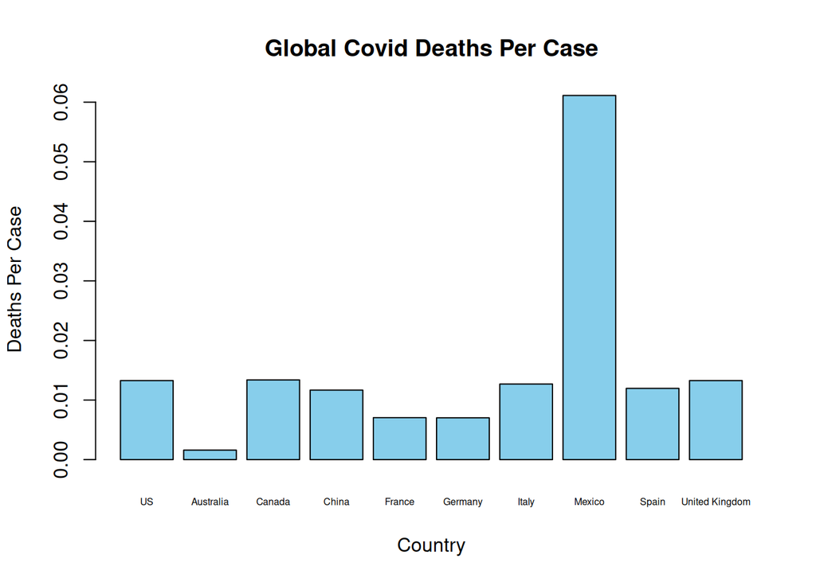

```r
# Producing the bar chart data
US_plot_1_data <- US_data  %>%
  select(Country, tot_cases, tot_deaths)  %>%
  group_by(Country) %>%
  summarise(deaths_per_case = sum(tot_deaths)/sum(tot_cases)) %>%
  ungroup()

global_plot_1_data <- global_data  %>%
  select(Country, tot_cases, tot_deaths) %>%
  filter(Country %in% c('Australia','Canada','China','France','Germany','Italy','Mexico','Spain','United Kingdom'))  %>%
  group_by(Country) %>%
  summarise(deaths_per_case = sum(tot_deaths)/sum(tot_cases)) %>%
  ungroup()

plot_1_data <- rbind(US_plot_1_data, global_plot_1_data)

# Barplot
barplot(plot_1_data$deaths_per_case,
        names.arg = plot_1_data$Country,
        col = "skyblue",
        main = "Global Covid Deaths Per Case",
        xlab = "Country",
        ylab = "Deaths Per Case",
        cex.names = 0.5)
```

```r
# Producing the scatter plot data
US_plot_2_data <- US_data  %>%
  select(Country, Year, tot_cases, tot_deaths)  %>%
  group_by(Country, Year) %>%
  summarise(deaths_per_case = sum(tot_deaths)/sum(tot_cases)) %>%
  ungroup()
```

```
## `summarise()` has regrouped the output.
## ℹ Summaries were computed grouped by Country and Year.
## ℹ Output is grouped by Country.
## ℹ Use `summarise(.groups = "drop_last")` to silence this message.
## ℹ Use `summarise(.by = c(Country, Year))` for per-operation grouping
##   (`?dplyr::dplyr_by`) instead.
```

```r
global_plot_2_data <- global_data  %>%
  select(Country, Year, tot_cases, tot_deaths) %>%
  filter(Country %in% c('Australia','Canada','China','France','Germany','Italy','Mexico','Spain','United Kingdom'))  %>%
  group_by(Country, Year) %>%
  summarise(deaths_per_case = sum(tot_deaths)/sum(tot_cases)) %>%
  ungroup()
```

```
## `summarise()` has regrouped the output.
## ℹ Summaries were computed grouped by Country and Year.
## ℹ Output is grouped by Country.
## ℹ Use `summarise(.groups = "drop_last")` to silence this message.
## ℹ Use `summarise(.by = c(Country, Year))` for per-operation grouping
##   (`?dplyr::dplyr_by`) instead.
```

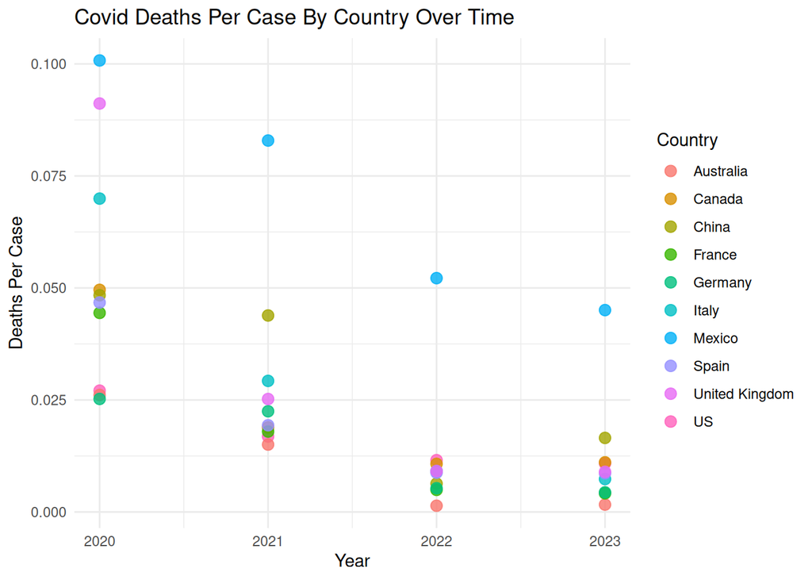

```r
plot_2_data <- rbind(US_plot_2_data, global_plot_2_data)

# Scatter plot
ggplot(plot_2_data, aes(x = Year, y = deaths_per_case, color = Country)) +
  geom_point(size = 3, alpha = 0.8) +
  theme_minimal() +
  labs(
    title = "Covid Deaths Per Case By Country Over Time",
    x = "Year",
    y = "Deaths Per Case",
    color = "Country"
  )
```

## US Based COVID Analysis

- Since 2020 and 2023 are partial years, focusing just on 2021 and 2022
- **The data overall shows the more cases there are per capita, the more deaths there are per capita.** This would support a theory of the health system of a state becomes overwhelmed with an influx of COVID cases, leading to more deaths.

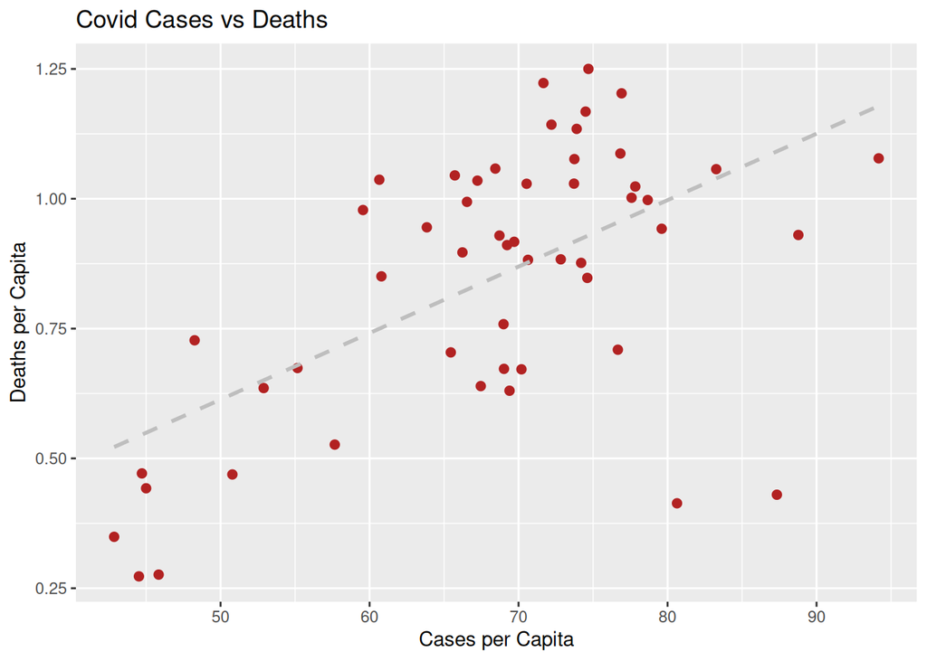

```r
# Aggregating to the state level, focusing on 2021 and 2022
US_plot_3_data <- US_data  %>%
  filter(Year %in% c(2021,2022)) %>%
  select(State, tot_pop, tot_cases, tot_deaths) %>%
  group_by(State) %>%
  summarise(deaths_per_case = sum(tot_deaths)/sum(tot_cases),
            cases_per_capita = sum(tot_cases)/sum(tot_pop),
            deaths_per_capita = sum(tot_deaths)/sum(tot_pop))%>%
  ungroup()

# Scatter plot of cases per capita against deaths per capita
ggplot(US_plot_3_data, aes(x = cases_per_capita, y = deaths_per_capita)) +
  geom_point(color = "firebrick", size = 2, alpha = 1) +
  geom_smooth(method = "lm", color = "gray", linetype = "dashed", se = FALSE) +
  labs(
    title = "Covid Cases vs Deaths",
    x = "Cases per Capita",
    y = "Deaths per Capita"
  )
```

## US State Covid Death Rate Predictions

- Since 2020 and 2023 are partial years, focusing just on 2021 and 2022
- The analysis overall shows that state is predictive of COVID death rates. Death rates per capita from COVID seem to persist by state between 2021 and 2022.
- Using GINI and RMSE as evaluation shows the data has some overfitting. The RMSE and GINI on train are essentially 0 and 1 respectively. This shows some shrinkage would be helpful. However, the GINI on the test data (did as the 2022 holdout vs the 2021 test) shows a GINI of ~0.88 which is strong.
- Looking at coefficients also shows State as a variable is predictive. More distant states like AK and HI have very large negative coefficients. Meanwhile several more densely populated states with NYC exposure like NY and NJ have rare positive coefficient estimates.

```r
# Aggregating to the state level, focusing on 2021 and 2022
# Training on 2021 data, testing on 2022 data
US_plot_4_data <- US_data  %>%
  filter(Year %in% c(2021,2022)) %>%
  mutate(train_test = if_else(Year == 2021, "train", "test")) %>%
  select(State, train_test, tot_pop, tot_cases, tot_deaths) %>%
  group_by(State, train_test) %>%
  summarise(deaths_per_case = sum(tot_deaths)/sum(tot_cases),
            cases_per_capita = sum(tot_cases)/sum(tot_pop),
            deaths_per_capita = sum(tot_deaths)/sum(tot_pop))%>%
  ungroup()
```

```
## `summarise()` has regrouped the output.
## ℹ Summaries were computed grouped by State and train_test.
## ℹ Output is grouped by State.
## ℹ Use `summarise(.groups = "drop_last")` to silence this message.
## ℹ Use `summarise(.by = c(State, train_test))` for per-operation grouping
##   (`?dplyr::dplyr_by`) instead.
```

```r
US_plot_4_data_train <- US_plot_4_data %>%
  filter(train_test == "train")

US_plot_4_data_test <- US_plot_4_data %>%
  filter(train_test == "test")

# Using a poisson model
model <- glm(deaths_per_capita ~ State,
             data = US_plot_4_data_train,
             family = poisson(link = "log"))
# Score on test
US_plot_4_data_test <- US_plot_4_data_test %>%
  mutate(pred_death_rate = predict(model, newdata = US_plot_4_data_test, type = "response"))

# Show model coefficients
summary(model)
```

```
##
## Call:
## glm(formula = deaths_per_capita ~ State, family = poisson(link = "log"),
##     data = US_plot_4_data_train)
##
## Coefficients:
##                           Estimate Std. Error z value Pr(>|z|)
## (Intercept)               -0.12420    1.06407  -0.117    0.907
## StateAlaska               -1.35224    2.34725  -0.576    0.565
## StateArizona               0.02474    1.49560   0.017    0.987
## StateArkansas             -0.11848    1.55142  -0.076    0.939
## StateCalifornia           -0.44533    1.70284  -0.262    0.794
## StateColorado             -0.64303    1.81274  -0.355    0.723
## StateConnecticut          -0.05627    1.52644  -0.037    0.971
## StateDelaware             -0.30383    1.63294  -0.186    0.852
## StateDistrict of Columbia -0.43518    1.69760  -0.256    0.798
## StateFlorida              -0.21301    1.59163  -0.134    0.894
## StateGeorgia              -0.15161    1.56520  -0.097    0.923
## StateHawaii               -1.72115    2.73175  -0.630    0.529
## StateIdaho                -0.55953    1.76451  -0.317    0.751
## StateIllinois             -0.18455    1.57923  -0.117    0.907
## StateIndiana              -0.13494    1.55822  -0.087    0.931
## StateIowa                 -0.21943    1.59446  -0.138    0.891
## StateKansas               -0.28101    1.62230  -0.173    0.862
## StateKentucky             -0.39502    1.67719  -0.236    0.814
## StateLouisiana             0.02658    1.49492   0.018    0.986
## StateMaine                -1.28432    2.28520  -0.562    0.574
## StateMaryland             -0.44520    1.70277  -0.261    0.794
## StateMassachusetts        -0.14989    1.56447  -0.096    0.924
## StateMichigan             -0.16673    1.57160  -0.106    0.916
## StateMinnesota            -0.56848    1.76955  -0.321    0.748
## StateMississippi           0.09974    1.46867   0.068    0.946
## StateMissouri             -0.43993    1.70005  -0.259    0.796
## StateMontana              -0.36979    1.66466  -0.222    0.824
## StateNebraska             -0.66394    1.82525  -0.364    0.716
## StateNevada               -0.21140    1.59092  -0.133    0.894
## StateNew Hampshire        -0.87673    1.96292  -0.447    0.655
## StateNew Jersey            0.18160    1.44099   0.126    0.900
## StateNew Mexico           -0.15812    1.56794  -0.101    0.920
## StateNew York              0.10343    1.46739   0.070    0.944
```

[output cut: 12 more lines]

```
## StateUtah                 -1.13374    2.15648  -0.526    0.599
## StateVermont              -1.69833    2.70549  -0.628    0.530
## StateVirginia             -0.61460    1.79601  -0.342    0.732
## StateWashington           -1.05560    2.09427  -0.504    0.614
## StateWest Virginia        -0.31566    1.63852  -0.193    0.847
## StateWisconsin            -0.54807    1.75810  -0.312    0.755
## StateWyoming              -0.48048    1.72131  -0.279    0.780
##
## (Dispersion parameter for poisson family taken to be 1)
##
##     Null deviance: 4.5083e+00  on 51  degrees of freedom
## Residual deviance: 1.2616e-15  on  0  degrees of freedom
## AIC: Inf
##
## Number of Fisher Scoring iterations: 4
```

```r
# Show rmse test
test_rmse_val <- sqrt(mean((US_plot_4_data_test$deaths_per_capita - US_plot_4_data_test$pred_death_rate)^2))
print(test_rmse_val)
```

```
## [1] 0.4645221
```

```r
# Show train rmse
US_plot_4_data_train <- US_plot_4_data_train %>%
  mutate(pred_death_rate = predict(model, newdata = US_plot_4_data_train, type = "response"))

train_rmse_val <- sqrt(mean((US_plot_4_data_train$deaths_per_capita - US_plot_4_data_train$pred_death_rate)^2))
print(train_rmse_val)
```

```
## [1] 2.362154e-12
```

```r
# Gini calc test
gini_val <- Gini(y_pred = US_plot_4_data_test$pred_death_rate, y_true = US_plot_4_data_test$deaths_per_capita)

print(gini_val)
```

```
## [1] 0.8774949
```

```r
# Gini on train
gini_val_train <- Gini(y_pred = US_plot_4_data_train$pred_death_rate, y_true = US_plot_4_data_train$deaths_per_capita)

print(gini_val_train)
```

```
## [1] 1
```

## Report Conclusion

**The overall analysis showed interesting outcomes from the COVID data analysis, on a global level and within the US.**

**The first question** of how death rates per cases compared across the global showed Mexico had high death rates among larger countries. Further the UK had high numbers relative to peer in the first year, but then their death rates came down. The US death rates per case seem to be in line with peer countries.

**The second question** of interest was the dynamic of death rates per capita and COVID cases per capita across the US. The data showed as case rates rose across states, death rates typically followed. This showed the potential for deaths to increase as the health system gets overwhelmed.

**The final question** surrounded was State within the US a good predictor of death rates. From the base analysis the answer is yes. Several more remote states had lower rates and several more metropolitan states had higher death rates. This seems to suggest social distancing ability impacts death rates.

## Bias introspection

I am native to the United States and had preconceived notions that state’s experienced different COVID death rates. While modeling showed using state as a predictor is strong, the model was overfit. I came to a conclusion this is fine since of the strong GINI metric, but the bias is the conclusion agreed with my apriori.

**There is also potential general bias within the data.** COVID saw different standards of record keeping with COVID. Different states and different countries sometimes only kept good numbers on deaths vs cases, especially once the pandemic went longer and some people didn’t report symptoms. Further, earlier on in the pandemic some people died before rigorous testing occurred. There was also politics in terms of outbreak numbers, causing some political pressure in record keeping.

- Showing code too